# Exemple de manipulation de rasters avec `R` et le package `Terra`

## Découper un raster

Il est possible de découper un raster de deux façons, soit avec la fonction `crop()` qui prend en compte l’emprise (la bbox) d’un objet, soit avec la fonction `mask()` qui découpe précisément selon la forme de l’objet.

Pour notre exemple nous allons utiliser la fonction `crop()` pour découper le MNT à l’emprise de la ligne.

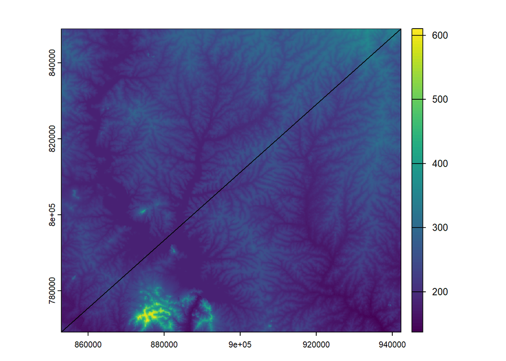

```r
MNT_transect <- crop(MNT, ligne)

plot(MNT_transect)
plot(ligne, add = T)
```

On peut aussi découper un raster selon un masque chargé dans la Section 4.2.2. Pour cela on utilise la fonction `mask()`

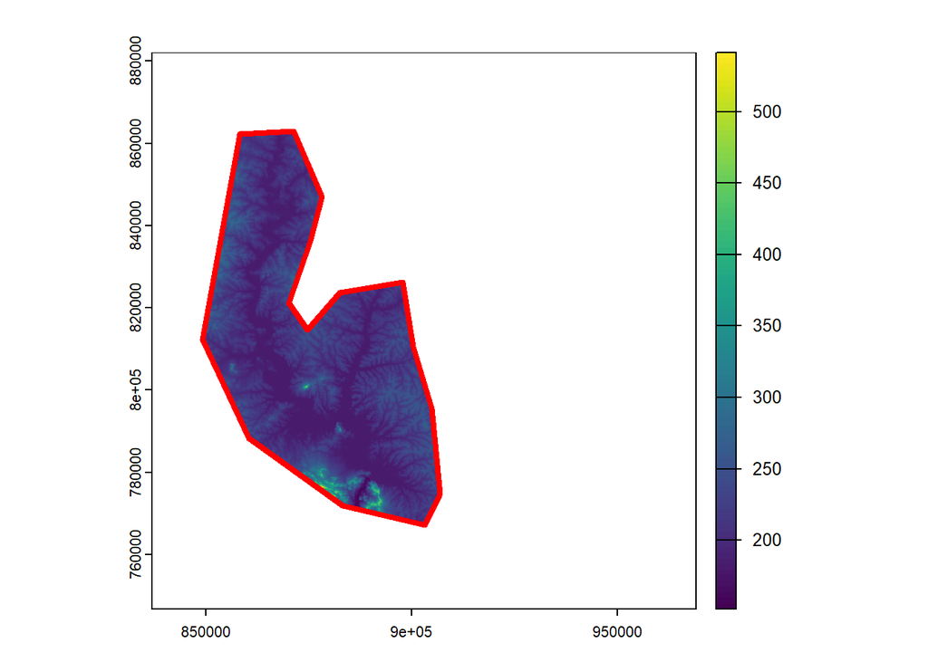

```r
MNT_mask <- mask(MNT, zone_etude)

plot(MNT_mask)
plot(zone_etude, add = TRUE, border = "red", lwd = 4) # 'border =' permet de colorer uniquement la bordure du polygone, lwd = correspond à l'épaisseur de ce contour.
```

Le *zone_etude* ne réduit pas l’emprise de la zone d’étude, mais remplace les valeurs en dehors du masque pas `NA`.

Pour obtenir une zone d’étude à la bonne emprise et découper, on combine les deux fonctions `crop()` et `mask()`.

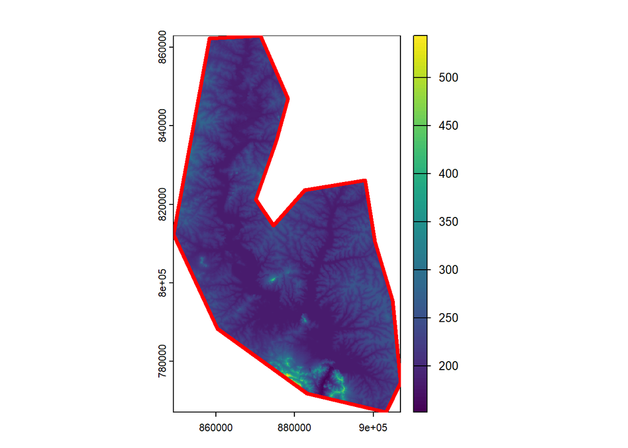

```r
MNT_mask <- crop(MNT_mask, zone_etude)

plot(MNT_mask)
plot(zone_etude, add = TRUE, border = "red", lwd = 4)
```

## Les références

Giraud, Timothée, et Hugues Pecout. 2024. *Géomatique avec R*. https://doi.org/https://doi.org/10.5281/zenodo.5906212.

Madelin, Malika. 2021. « Analyse d’images raster (et télédétection) ». https://mmadelin.github.io/sigr2021/SIGR2021_raster_MM.html.

Nowosad, Jakub. 2021. « Image processing and all things raster ». https://nowosad.github.io/SIGR2021/workshop2/workshop2.html.